### Lab 4 Solution

1. Load in the merged NYC weather and DJI data from the previous lab.

```r
library(stargazer)
library(tidyverse)
data <- read_csv("weather and dji.csv")
```

2. Create a new variable that takes on value “yes” if there was some precipitation and “no” otherwise. How many days were there with precipiation compared to days without?

```r
data$precp <- ifelse(data$PRCP>0,"yes","no")
table(data$precp)
```

```
##
##    no   yes
## 13097  6548
```

The days without precipiation outnumber days with about 2 to 1.

3. What is the mean return on days when there was precipitation compared to when there was no precipitation? Is the difference statistically significant?

```r
data <- as.data.frame(data)
stargazer(select(filter(data, precp == "yes"),ret), type = "text")
```

```
##
## ============================================
## Statistic   N   Mean  St. Dev.  Min    Max
## --------------------------------------------
## ret       6,548 0.007  0.914   -7.701 10.878
## --------------------------------------------
```

```r
stargazer(select(filter(data, precp == "no"),ret), type = "text")
```

```
##
## ==============================================
## Statistic   N    Mean  St. Dev.   Min    Max
## ----------------------------------------------
## ret       13,097 0.040  0.936   -22.625 11.080
## ----------------------------------------------
```

```r
t.test(data$ret ~ data$precp)
```

```
##
##  Welch Two Sample t-test
##
## data:  data$ret by data$precp
## t = 2.3653, df = 13367, p-value = 0.01803
## alternative hypothesis: true difference in means is not equal to 0
## 95 percent confidence interval:
##  0.005652302 0.060338609
## sample estimates:
##  mean in group no mean in group yes
##       0.039765334       0.006769878
```

The average return is a bit higher on days with no precipiation. The `t.test` function returns t-statistic of 2.37 with p-value of 0.018. so at 5 percent level the difference between the means *is* statistically significant. Let’s see if we get the same result when we do the test by hand: $t=\frac{0.040-0.007}{\sqrt{0.936^2/13,097+0.914^2/6,548}}=2.37$ which is the same result that the `t.test()` function returned above.

4. Let’s plot the densities of daily returns when there is no precipiation overlayed with density of returns when there is precipiation. (Hint: You can limit the range of displayed x axis by including the following to your ggplot `coord_cartesian(xlim = c(-2, 2))`)

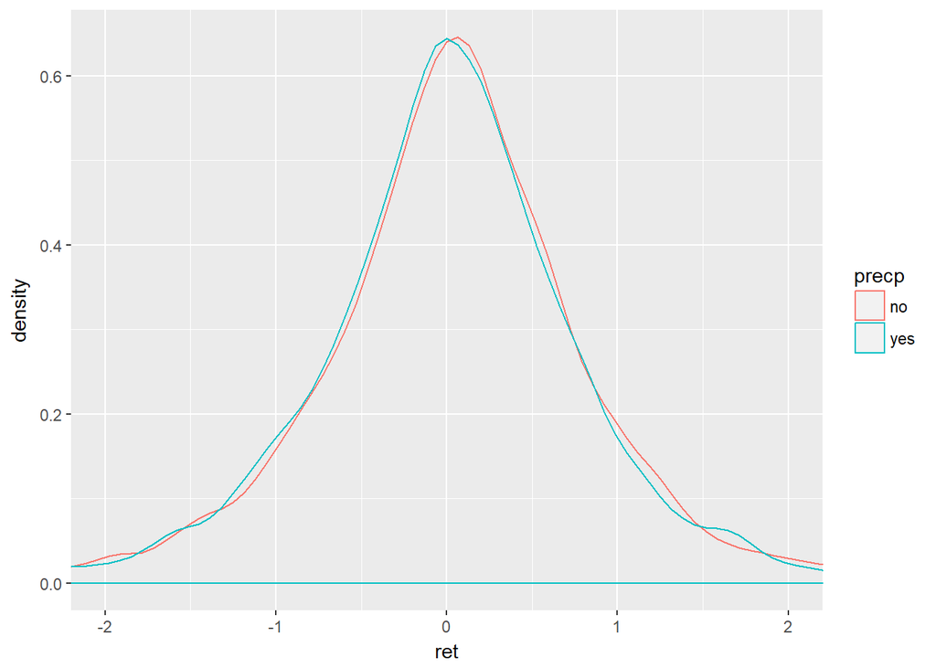

```r
ggplot(data, aes(x=ret, color=precp)) + geom_density() + coord_cartesian(xlim = c(-2, 2))
```

5. What do the two densities show?

The densities are nearly identical, but the density showing the distribution of returns on days without precipitation is a bit to the right of the density of returns with precipitation. This shows that precipitation has a small negative effect on daily returns, consistent with our t-test.